# Value at Risk avec l’action ORPEA

### 1.2.5 GARCH(1,1)

Soit un GARCH(1,1) :
$$\begin{equation}
v_t = \sigma_t\epsilon_t \\
\sigma_t^2 = \alpha_0 + \alpha_1v_{t-1}^2 + \beta_1\sigma_{t-1}^2 \\
avec \ \alpha_1 \ge 0, \ \beta_1 \le 1 \ et \ \alpha_1 + \beta_1 < 1
\tag{1.6}
\end{equation}$$

```r
spec_sged_garch = ugarchspec(distribution.model="sged")
fit_sged_garch = ugarchfit(spec = spec_sged_garch, data = rt,out.sample=length(rtt),solver="hybrid")
show(fit_sged_garch)
```

```
##
## *---------------------------------*
## *          GARCH Model Fit        *
## *---------------------------------*
##
## Conditional Variance Dynamics
## -----------------------------------
## GARCH Model  : sGARCH(1,1)
## Mean Model   : ARFIMA(1,0,1)
## Distribution : sged
##
## Optimal Parameters
## ------------------------------------
##         Estimate  Std. Error  t value Pr(>|t|)
## mu      0.000732    0.000211   3.4611 0.000538
## ar1     0.910087    0.026136  34.8212 0.000000
## ma1    -0.927302    0.024004 -38.6316 0.000000
## omega   0.000024    0.000015   1.6188 0.105494
## alpha1  0.085609    0.032507   2.6336 0.008449
## beta1   0.766880    0.117172   6.5449 0.000000
## skew    1.054468    0.025197  41.8489 0.000000
## shape   1.196407    0.058251  20.5388 0.000000
##
## Robust Standard Errors:
##         Estimate  Std. Error   t value Pr(>|t|)
## mu      0.000732    0.000179    4.0872 0.000044
## ar1     0.910087    0.008153  111.6240 0.000000
## ma1    -0.927302    0.008086 -114.6730 0.000000
## omega   0.000024    0.000021    1.1515 0.249510
## alpha1  0.085609    0.045785    1.8698 0.061509
## beta1   0.766880    0.165366    4.6375 0.000004
## skew    1.054468    0.022507   46.8498 0.000000
## shape   1.196407    0.061750   19.3750 0.000000
##
## LogLikelihood : 4601.338
##
## Information Criteria
## ------------------------------------
##
## Akaike       -5.9887
```

[output cut: 49 more lines]

```
## Negative Sign Bias  0.6891 0.4908
## Positive Sign Bias  1.5078 0.1318
## Joint Effect        2.7676 0.4289
##
##
## Adjusted Pearson Goodness-of-Fit Test:
## ------------------------------------
##   group statistic p-value(g-1)
## 1    20     15.65       0.6806
## 2    30     14.11       0.9908
## 3    40     29.70       0.8584
## 4    50     38.10       0.8701
##
##
## Elapsed time : 4.280557
```

Le coefficient associé à alpha1 n’est pas significatif au seuil de 5%. Ce modèle n’est pas valide pour nos données.

## 1.3 Prévisions

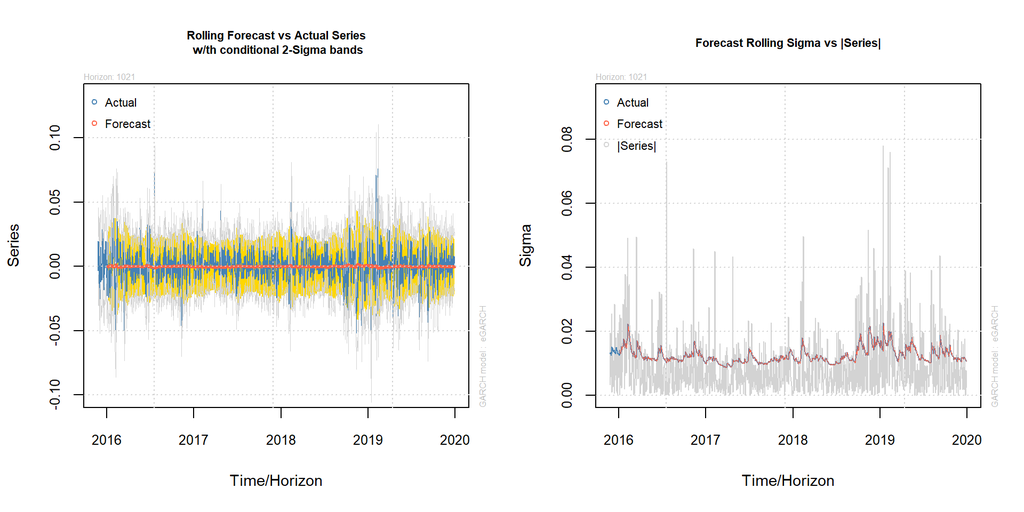

```r
prev = ugarchforecast(fit_sged_eg, n.ahead=length(rtt),n.roll=length(rtt))
op <- par(mfrow = c(1,2))
plot(prev,which=2)
plot(prev,which=4)
```

Ces deux graphiques illustrent la prévision conditionnelle de la variance sur rtt. On remarque avec celui de droite que la courbe rouge des prévisions suit les hausses mais ne mesure pas assez les amplitudes.

### 1.3.1 Estimation par fenêtre glissante

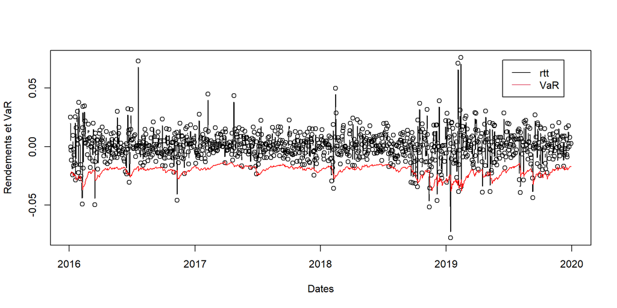

Figure 1.4: Comparaison de la VaR estimée par fenêtre glissante

```r
no_cores <- parallel::detectCores() - 1
cl <- makeCluster(no_cores)
spec_sged_eg = ugarchspec(variance.model=list(model="eGARCH", garchOrder=c(1,1)),
                                    mean.model=list(armaOrder=c(1,1),include.mean=F,external.regressors=as.matrix(cbind(mai))),distribution.model="sged")
roll=ugarchroll(spec_sged_eg, data=rt,n.ahead=1,forecast.length=length(rtt),refit.every=1,
      refit.window="moving",solver = "hybrid", cluster=cl,fit.control = list(),calculate.VaR=TRUE,VaR.alpha=0.05,keep.coef = TRUE)
stopCluster(cl)
valueatrisk<-zoo(roll@forecast$VaR[,1])
reelles<-zoo(roll@forecast$VaR[,2])
index<-rownames(roll@forecast$VaR)
plot(dates[1535:N],reelles,type='b',xlab="Dates",ylab="Rendements et VaR")
lines(dates[1535:N],valueatrisk,type='l',col="red")
legend("topright",inset=.05,c("rtt","VaR"),col=1:2,lty=c(1,1))
```

Ce graphique permet de donner une vision d’ensemble sur la VaR estimée à chaque période comparée à la valeur effective de cette même période. Un espace un peu plus chahuté autour de 2019 semble se dessiner. On peut observer de multiples dépassements de la VaR. Au contraire l’année 2017 subit un unique dépassement en fin d’année. Un étude chiffrée nous donnera l’occasion de préciser les violations de la VaR.